# Applications of Inference Frameworks: Linear Regression

## Linear regression

Generate \(n=30\) random data points: \(X \sim \mathcal{N}(10, 1)\) and \(Y = 2.3 X + \epsilon\), where \(\epsilon \sim \mathcal{N}(1, 1)\):

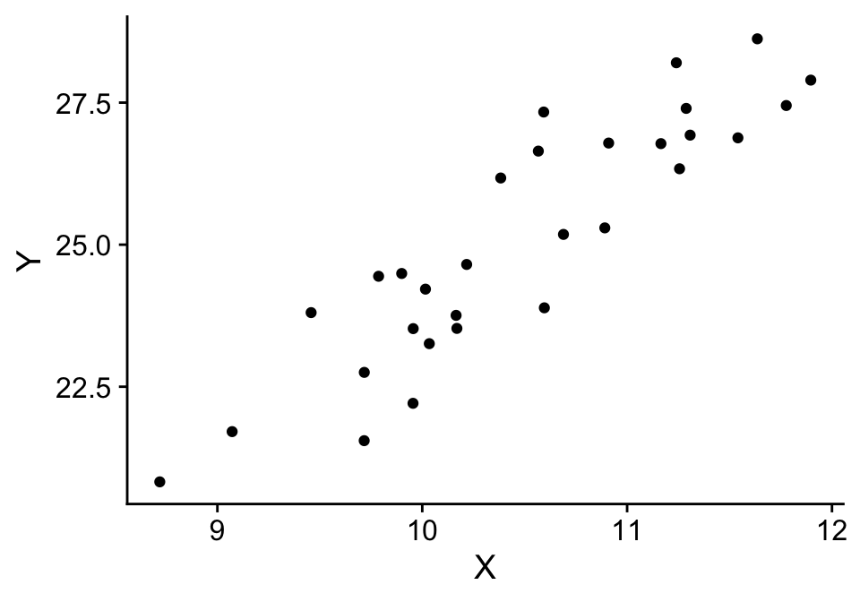

What values of \(\theta_1\) and \(\theta_2\) provide the best fit line through \(Y\) as a function of \(X\)?

\[Y = \theta_1 + \theta_2 X\]

## Frameworks for inference

1. Analytical
2. Maximum likelihood
   - Minimizing the residual sum of squares is numerically equal to *maximizing* the model likelihood.
3. Resampling
4. Bayesian

## Errors are normally distributed around the regression line

[figure not shown]

How would probabilities change for a different slope estimate?

## What is the likelihood of an observed value given a regression model?

Define a function to calculate the likelihood of an observed value \(Y_i\) given the mean (\(\mu\)) and standard deviation (\(\sigma\)). Default to the standard normal distribution \(\mathcal{N}(0,1)\).

\[\phi\left(Y_i\right) = \frac{1}{\sqrt{2\pi\sigma^{2}}} e^{\frac{-\left(Y_i-\mu\right)^{2}}{2\sigma^{2}}}\]

## Define a model

\[y = \bar{Y} + bX\]

\[b = 0\]

This is a flat line (\(b = 0\)) through the mean of \(Y\).

## Define a model

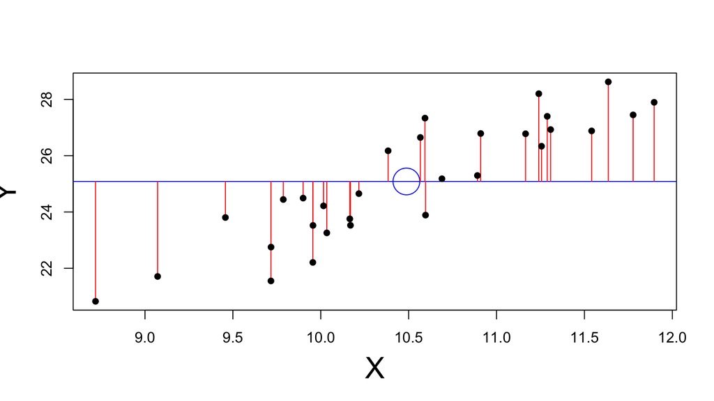

## Calculate the predicted values

Just the mean of \(Y\) repeated 30 times.

```r
Y_bar <- mean(Y)
Y_hat <- rep(Y_bar, length(Y))
Y_hat
```

```
##  [1] 25.08401 25.08401 25.08401 25.08401 25.08401 25.08401 25.08401 25.08401
##  [9] 25.08401 25.08401 25.08401 25.08401 25.08401 25.08401 25.08401 25.08401
## [17] 25.08401 25.08401 25.08401 25.08401 25.08401 25.08401 25.08401 25.08401
## [25] 25.08401 25.08401 25.08401 25.08401 25.08401 25.08401
```

## Likelihood of a predicted value of \(Y\)

\[\phi\left(Y_i\right)=\frac{1}{\sqrt{2\pi\hat{\sigma}^2}} e^{\frac{-\left(Y_i - \mu\right)^{2}}{2\hat{\sigma}^2}}\]

- \(\mu =\) the predicted value \(\hat{Y}_i\)
- Need the estimate of the residual variance \(\left(\hat{\sigma}^2\right)\).

## Residual variance

\[\hat{\sigma}^2 = \frac{\Sigma_i\left(Y_i - \hat{Y}_i\right)^2}{n}\]

This is a biased estimate, but that’s ok. It is how model likelihoods are calculated in this case.

\[s^2 = MSE = \frac{n}{n-2}\left(\hat{\sigma}^2\right)\]

For non-small \(n\), \(s^2 \approx \left(\hat{\sigma}^2\right)\). Here ~7% difference.

## Calculate the estimated residual variance and standard deviation

```r
# Estimated variance
var_hat <- sum((Y - Y_hat)^2) / (length(Y))
var_hat
```

```
## [1] 4.475126
```

```r
sd_hat <- sqrt(var_hat)
sd_hat
```

```
## [1] 2.115449
```

## Likelihoods for observed \(Y\)s

```r
# Check the likelihood for the first Y
dnorm(Y[1], mean = Y_hat[1], sd = sd_hat)
```

```
## [1] 0.1846934
```

```r
# Calculate for all Ys
(liks_Y <- dnorm(Y, mean = Y_hat, sd = sd_hat))
```

```
##  [1] 0.18469336 0.15704719 0.18764577 0.16075453 0.04653338 0.18838780
##  [7] 0.02486777 0.18014534 0.07794390 0.10093788 0.14354376 0.17341633
## [13] 0.16516072 0.07484938 0.12993261 0.14381858 0.13683565 0.14362128
## [19] 0.18136842 0.04674421 0.13151337 0.15486450 0.12898315 0.10364549
## [25] 0.10708752 0.10273798 0.15828717 0.13630709 0.05285416 0.06367672
```

## Model Likelihood (\(\mathcal{L}\))

For a set of \(Y_i\) and parameters (\(\Theta\); i.e., slope and intercept) the likelihood of the model is the product of their individual probabilities:

\[\mathcal{L}\left(\left\{ Y_{i}\right\} _{i=1}^{n};\Theta\right) = \prod_{i=1}^{n}\phi\left(Y_{i}; \Theta\right)\]

\[\log\left(\mathcal{L}\left(\left\{ Y_{i}\right\} _{i=1}^{n};\Theta\right)\right) = \sum_{i=1}^{n} \log\left(\phi\left(Y_{i};\Theta\right)\right)\]

## Model Likelihood (\(\mathcal{L}\))

```r
# Sum of the log-likelihoods
sum(log(liks_Y))
```

```
## [1] -65.04617
```

## Likelihood from linear regression with \(b = 0\)

Fit a linear model (`lm()`) with only an intercept (`~ 1`) and use the built-in function `logLik()` to extract the log-likelihood.

```r
fm <- lm(Y ~ 1)
logLik(fm)
```

```
## 'log Lik.' -65.04617 (df=2)
```

## Maximizing the log-Likelihood

Function to calculate the log-likelihood. Input the slope (\(b\)) and observed values of \(X\) and \(Y\). Return the log-likelihood.

```r
log_lik <- function(b, X, Y){
  Y_bar <- mean(Y)
  X_bar <- mean(X)
  a <- Y_bar - b * X_bar
  Y_hat <- a + b * X
  var_hat <- sum((Y - Y_hat) ^ 2) / (length(Y))
  sd_hat <- sqrt(var_hat)
  liks_Y <- dnorm(Y, mean = Y_hat, sd = sd_hat)
  return(sum(log(liks_Y)))
}
```

## Maximizing the log-Likelihood

For a range of \(b\) from -10 to 10 in increments of 0.01, calculate the log-likelihood of the model. Save to a variable called `lls`. Then find the maximum value of `lls`, the associated \(b\) and log-likelihood.

```r
b <- seq(-10, 10, by = 0.01)
lls <- numeric(length(b))
for (ii in 1:length(b)) {
  lls[ii] <- log_lik(b[ii], X, Y)
}

# Location of maximum log-likelihood
max.ll <- lls[which.max(lls)]

# Slope at maximum log-likelihood
b_hat <- b[which.max(lls)]
```

## Maximizing the log-Likelihood

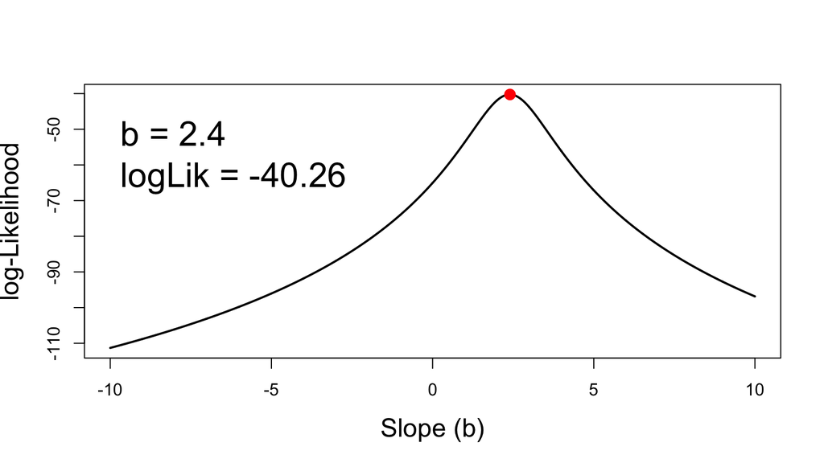

## Maximizing the log-Likelihood

```r
max.ll
```

```
## [1] -40.25846
```

```r
fm <- lm(Y ~ 1 + X) # Fit model with intercept and slope
logLik(fm)      # Use built-in function to extract log-likelihood
```

```
## 'log Lik.' -40.25821 (df=3)
```

The values are not identical, because we only calculated \(b\) in increments of 0.01.

## Bayesian priors

What priors for intercept (\(\theta_0\)) and slope (\(\theta_1\))?

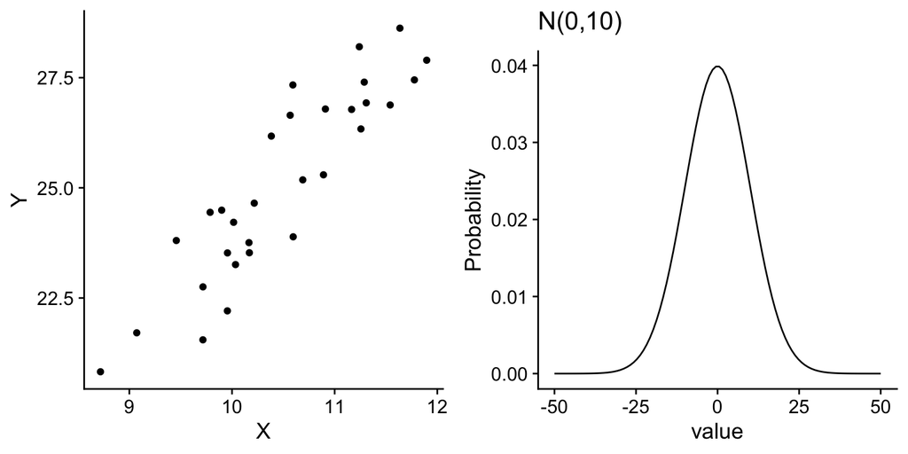

## Bayesian

```r
fm <- ulam(
  alist(
    Y ~ normal(mu, sigma),
    mu <- theta_0 + theta_1 * X,
    theta_0 ~ normal(0, 10),
    theta_1 ~ normal(0, 5),
    sigma ~ exponential(0.5)
  ),
  data = M,
  iter = 1e4,
  chains = 4)
```

## Bayesian sampling

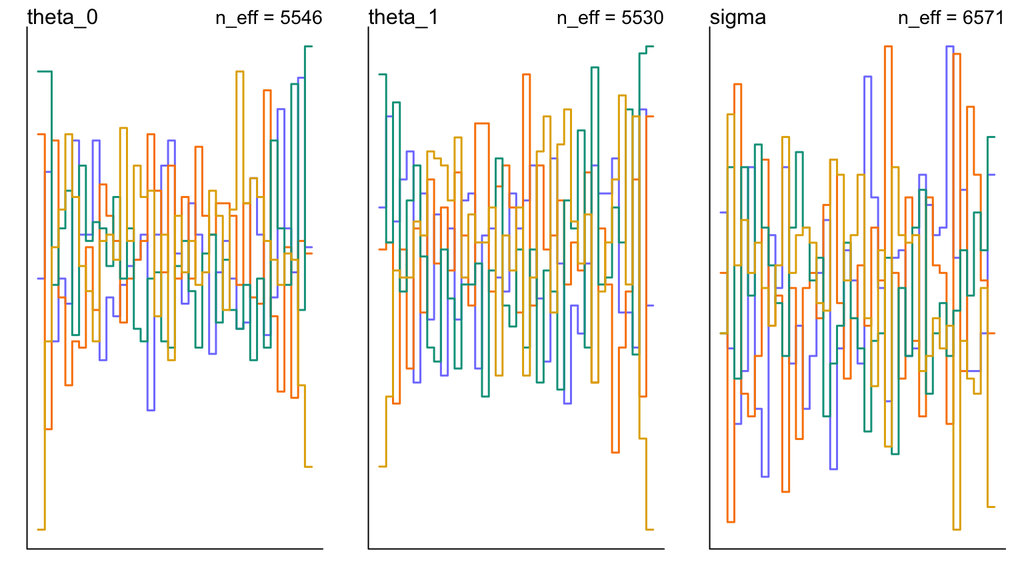

## Bayesian posteriors

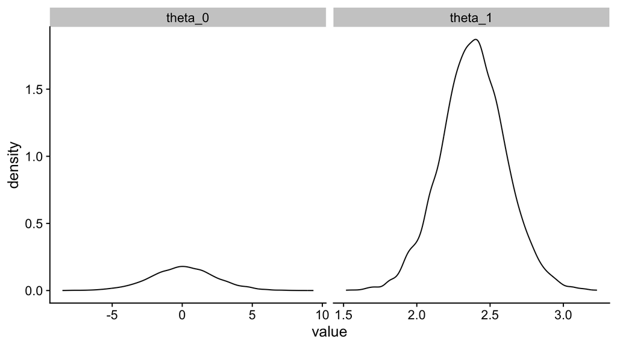

## Bayesian summary

```r
precis(fm, digits = 4)
```

```
##              mean        sd       5.5%    94.5%    n_eff    Rhat4
## theta_0 0.0662149 2.3313599 -3.6429631 3.749698 5546.391 1.000154
## theta_1 2.3854611 0.2216609  2.0345014 2.737150 5530.179 1.000130
## sigma   0.9920605 0.1387213  0.7994097 1.232351 6570.542 1.000708
```

```r
coef(lm(Y ~ X, data = M))
```

```
## (Intercept)           X
## -0.03540546  2.39524849
```

## A sample of Bayesian samples

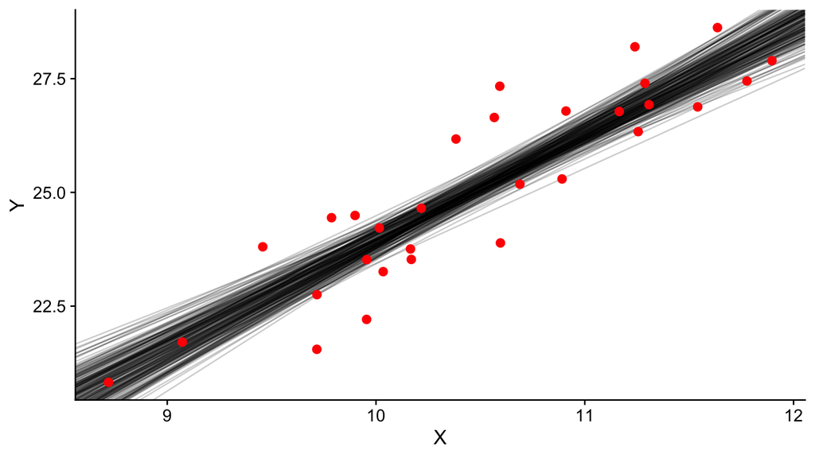

## Key features

- Analytical solutions are fast, hand-calculable
  - Unavailable for complex models (e.g., hierarchical models)
- Analytical and maximum likelihood estimates will converge given enough precision
- Bayesian estimates can include prior knowledge
- Bayesian estimates will converge on ML estimates for sufficiently flat priors and/or sufficient data

## Key points

Comparison of means between groups:

- Categorical predictor variables (factors)

Linear relationships

- Continuous predictor variables